# Aalto Pro/Diploma in Artificial Intelligence: Project work

## APPENDIX 1: Code of the project.

```python
import numpy as np
import pandas as pd
import matplotlib.pyplot as plt
import seaborn as sns
```

or:

```python
%matplotlib inline
```

```python
def LoadData(filename):# FILENAME ON INPUT-PARAMETRINÄ LOADDATA-FUNKTIOLLE. FILENAME ANNETAAN SIIS FUNKTIOTA KÄYTETTÄESSÄ.
    """
    Load the csv reading the file with the filename given as a parameter.
    Print the sample size m and the feature length n.

    :input: String path to the file

    :return: pandas dataframe of shape=(m, n, ty), the sample size m and the feature length n
    and the data type ty. In this case no conversion to Numpy array
    """

    df = pd.read_csv(filename, delimiter=';')
    #X = df.values # convert the data frame to numpy array
    n = df.shape[1]        # second element of "dimension" is the number of cols
    m = df.shape[0]        # first element of dimension is the number of rows
    ty = type(df)
    print('sample size m=',m)
    print('feature length n=',n)
    print('the data type is', ty)
    return df, m, n, ty
```

```python
FWAsource, m, n, ty, = LoadData('MS6/LEVEL_TANK_A0.csv')
```

```
sample size m= 402860
feature length n= 5
the data type is <class 'pandas.core.frame.DataFrame'>
```

```python
FWAsource.head()
```

|  | VarName | TimeString | VarValue | Validity | Time_ms |
| --- | --- | --- | --- | --- | --- |
| 0 | FOODWASTE_TANK_A_LEVEL_TREND | 25.02.2018 16:07:23 | 47 | 1 | 43156671788,5185 |
| 1 | HARSLEV_PUMP_1_1PM_1_STATUS | 25.02.2018 16:07:25 | 20 | 1 | 43156671811,9097 |
| 2 | THREEWAY_VALVE_1_1PV4_STATUS | 25.02.2018 16:07:25 | 5 | 1 | 43156671811,9097 |
| 3 | HARSLEV_PUMP_1_1PM_1_STATUS | 25.02.2018 16:07:27 | 20 | 1 | 43156671835,2894 |
| 4 | THREEWAY_VALVE_1_1PV4_STATUS | 25.02.2018 16:07:27 | 5 | 1 | 43156671835,2894 |

```python
FWBsource, m, n, ty, = LoadData('MS6/LEVEL_TANK_B0.csv')
```

```
sample size m= 402860
feature length n= 5
the data type is <class 'pandas.core.frame.DataFrame'>
```

```python
FWBsource.tail()
```

|  | VarName | TimeString | VarValue | Validity | Time_ms |
| --- | --- | --- | --- | --- | --- |
| 402855 | HARSLEV_PUMP_1_2PM_1_STATUS | 01.03.2018 14:19:30 | 20 | 1 | 43160596875,2315 |
| 402856 | THREEWAY_VALVE_1_2PV4_STATUS | 01.03.2018 14:19:30 | 5 | 1 | 43160596875,2315 |
| 402857 | FOODWASTE_TANK_B_LEVEL_TREND | 01.03.2018 14:19:31 | 21 | 1 | 43160596886,9329 |
| 402858 | HARSLEV_PUMP_1_2PM_1_STATUS | 01.03.2018 14:19:32 | 20 | 1 | 43160596898,6343 |
| 402859 | THREEWAY_VALVE_1_2PV4_STATUS | 01.03.2018 14:19:32 | 5 | 1 | 43160596898,6343 |

```python
BWsource, m, n, ty, = LoadData('MS6/LEVEL_BIOSLUDGETANK0.csv')
```

```
sample size m= 400952
feature length n= 5
the data type is <class 'pandas.core.frame.DataFrame'>
```

```python
BWsource.head()
```

|  | VarName | TimeString | VarValue | Validity | Time_ms |
| --- | --- | --- | --- | --- | --- |
| 0 | BIO_SLUDGE_MIXING_STATUS | 17.02.2018 21:03:26 | 0 | 1 | 43148877388,0556 |
| 1 | BIO_SLUDGE_TANK_LEVEL_TREND | 17.02.2018 21:03:26 | 19 | 1 | 43148877388,0556 |
| 2 | BIO_SLUDGE_MIXING_STATUS | 17.02.2018 21:03:31 | 0 | 1 | 43148877446,5162 |
| 3 | BIO_SLUDGE_TANK_LEVEL_TREND | 17.02.2018 21:03:31 | 19 | 1 | 43148877446,5162 |
| 4 | BIO_SLUDGE_MIXING_STATUS | 17.02.2018 21:03:36 | 0 | 1 | 43148877505 |

```python
DWsource, m, n, ty, = LoadData('MS6/Inc_1_datalog_functions0.csv')
```

```
sample size m= 500000
feature length n= 5
the data type is <class 'pandas.core.frame.DataFrame'>
```

```python
DWsource.head() # Contains waste burning data. Not useable for waste flow prediction.
```

|  | VarName | TimeString | VarValue | Validity | Time_ms |
| --- | --- | --- | --- | --- | --- |
| 0 | inc_1_primary_burner_status | 17.02.2018 21:03:15 | 0 | 1 | 43148877259,4097 |
| 1 | inc_1_secondary_burner_status | 17.02.2018 21:03:15 | -20 | 1 | 43148877259,4097 |
| 2 | inc_1_lower_feeding_gate_status | 17.02.2018 21:03:15 | -10 | 1 | 43148877259,4097 |
| 3 | inc_1_medical_flap_status | 17.02.2018 21:03:15 | -5 | 1 | 43148877259,4097 |
| 4 | inc_1_primary_burner_status | 17.02.2018 21:03:16 | 0 | 1 | 43148877271,0995 |

```python
# A test print of data types
print(DWsource.columns)
print(DWsource.info())
```

```
Index(['VarName', 'TimeString', 'VarValue', 'Validity', 'Time_ms'], dtype='object')
<class 'pandas.core.frame.DataFrame'>
RangeIndex: 500000 entries, 0 to 499999
Data columns (total 5 columns):
VarName       500000 non-null object
TimeString    500000 non-null object
VarValue      500000 non-null int64
Validity      500000 non-null int64
Time_ms       500000 non-null object
dtypes: int64(2), object(3)
memory usage: 19.1+ MB
None
```

```python
IncVar, m, n, ty, = LoadData('MS6/Inc_1_datalog_var1.csv')
```

```
sample size m= 500000
feature length n= 5
the data type is <class 'pandas.core.frame.DataFrame'>
```

```python
IncVar.head() # Contains waste burning data. Not useable for waste flow prediction.
```

|  | VarName | TimeString | VarValue | Validity | Time_ms |
| --- | --- | --- | --- | --- | --- |
| 0 | inc_1_primary_chamber_temperature | 07.01.2018 22:57:15 | 930 | 1 | 43107956427,9745 |
| 1 | inc_1_secondary_chamber_temperature | 07.01.2018 22:57:15 | 856 | 1 | 43107956427,9861 |
| 2 | inc_1_fluegas_temperature | 07.01.2018 22:57:15 | 222 | 1 | 43107956427,9861 |
| 3 | inc_1_underpressure | 07.01.2018 22:57:15 | 20 | 1 | 43107956427,9861 |
| 4 | inc_1_primary_chamber_temperature | 07.01.2018 22:57:20 | 931 | 1 | 43107956486,4583 |

```python
def Datetime(df):
    """
    Converts the str-type TimeString into more useful Pandas DateTime form.

    Prints the head of the DataFrame after conversion and the data type of the DateTime column.

    :input: Name of the dataframe and the TimeString column of the DF in question.

    :return: pandas dataframe with the DateTime and its data type.
    """

    df['DateTime'] = pd.to_datetime(df.TimeString, format = '%d.%m.%Y %H:%M:%S')
    dty = type(df.DateTime)    # Returns datatype
    print(df.head())
    print('The time data type is now: ',dty)
    return df, dty
```

```python
Datetime(DWsource)
```

[output not shown]

```python
Datetime(BWsource)
```

[output not shown]

```python
Datetime(FWAsource)
```

[output not shown]

```python
Datetime(FWBsource)
```

[output not shown]

### Check that the DateTime-column is produced by the function:

```python
DWsource.head()
```

|  | VarName | TimeString | VarValue | Validity | Time_ms | DateTime |
| --- | --- | --- | --- | --- | --- | --- |
| 0 | inc_1_primary_burner_status | 17.02.2018 21:03:15 | 0 | 1 | 43148877259,4097 | 2018-02-17 21:03:15 |
| 1 | inc_1_secondary_burner_status | 17.02.2018 21:03:15 | -20 | 1 | 43148877259,4097 | 2018-02-17 21:03:15 |
| 2 | inc_1_lower_feeding_gate_status | 17.02.2018 21:03:15 | -10 | 1 | 43148877259,4097 | 2018-02-17 21:03:15 |
| 3 | inc_1_medical_flap_status | 17.02.2018 21:03:15 | -5 | 1 | 43148877259,4097 | 2018-02-17 21:03:15 |
| 4 | inc_1_primary_burner_status | 17.02.2018 21:03:16 | 0 | 1 | 43148877271,0995 | 2018-02-17 21:03:16 |

```python
FWAsource.head()
```

|  | VarName | TimeString | VarValue | Validity | Time_ms | DateTime |
| --- | --- | --- | --- | --- | --- | --- |
| 0 | FOODWASTE_TANK_A_LEVEL_TREND | 25.02.2018 16:07:23 | 47 | 1 | 43156671788,5185 | 2018-02-25 16:07:23 |
| 1 | HARSLEV_PUMP_1_1PM_1_STATUS | 25.02.2018 16:07:25 | 20 | 1 | 43156671811,9097 | 2018-02-25 16:07:25 |
| 2 | THREEWAY_VALVE_1_1PV4_STATUS | 25.02.2018 16:07:25 | 5 | 1 | 43156671811,9097 | 2018-02-25 16:07:25 |
| 3 | HARSLEV_PUMP_1_1PM_1_STATUS | 25.02.2018 16:07:27 | 20 | 1 | 43156671835,2894 | 2018-02-25 16:07:27 |
| 4 | THREEWAY_VALVE_1_1PV4_STATUS | 25.02.2018 16:07:27 | 5 | 1 | 43156671835,2894 | 2018-02-25 16:07:27 |

```python
FWBsource.head()
```

|  | VarName | TimeString | VarValue | Validity | Time_ms | DateTime |
| --- | --- | --- | --- | --- | --- | --- |
| 0 | FOODWASTE_TANK_B_LEVEL_TREND | 25.02.2018 16:07:23 | 14 | 1 | 43156671788,5185 | 2018-02-25 16:07:23 |
| 1 | HARSLEV_PUMP_1_2PM_1_STATUS | 25.02.2018 16:07:25 | 20 | 1 | 43156671811,9097 | 2018-02-25 16:07:25 |
| 2 | THREEWAY_VALVE_1_2PV4_STATUS | 25.02.2018 16:07:25 | 5 | 1 | 43156671811,9097 | 2018-02-25 16:07:25 |
| 3 | HARSLEV_PUMP_1_2PM_1_STATUS | 25.02.2018 16:07:27 | 20 | 1 | 43156671835,2894 | 2018-02-25 16:07:27 |
| 4 | THREEWAY_VALVE_1_2PV4_STATUS | 25.02.2018 16:07:27 | 5 | 1 | 43156671835,3009 | 2018-02-25 16:07:27 |

```python
BWsource.head()
```

|  | VarName | TimeString | VarValue | Validity | Time_ms | DateTime |
| --- | --- | --- | --- | --- | --- | --- |
| 0 | BIO_SLUDGE_MIXING_STATUS | 17.02.2018 21:03:26 | 0 | 1 | 43148877388,0556 | 2018-02-17 21:03:26 |
| 1 | BIO_SLUDGE_TANK_LEVEL_TREND | 17.02.2018 21:03:26 | 19 | 1 | 43148877388,0556 | 2018-02-17 21:03:26 |
| 2 | BIO_SLUDGE_MIXING_STATUS | 17.02.2018 21:03:31 | 0 | 1 | 43148877446,5162 | 2018-02-17 21:03:31 |
| 3 | BIO_SLUDGE_TANK_LEVEL_TREND | 17.02.2018 21:03:31 | 19 | 1 | 43148877446,5162 | 2018-02-17 21:03:31 |
| 4 | BIO_SLUDGE_MIXING_STATUS | 17.02.2018 21:03:36 | 0 | 1 | 43148877505 | 2018-02-17 21:03:36 |

```python
def Filtvar(df, col):
    """
    Picks up the rows with desired variables

    :input: Name of the dataframe and the desired variable in quotes ('').

    :return: pandas dataframe with only the desired variable in the VarName-column.
    In addition, returns the dimensions of the new filtered DataFrame.
    """

    df = df[df.VarName == col]
    n = df.shape[1]        # second element of "dimension" is the number of cols
    m = df.shape[0]        # first element of dimension is the number of rows

    print('sample size m=',m)
    print('feature length n=',n)

    return df, m, n
```

### Apply Filtvar():

```python
DW, m, n, = Filtvar(DWsource, 'inc_1_lower_feeding_gate_status')
```

```
sample size m= 125000
feature length n= 6
```

```python
DW.head()
```

|  | VarName | TimeString | VarValue | Validity | Time_ms | DateTime |
| --- | --- | --- | --- | --- | --- | --- |
| 2 | inc_1_lower_feeding_gate_status | 17.02.2018 21:03:15 | -10 | 1 | 43148877259,4097 | 2018-02-17 21:03:15 |
| 6 | inc_1_lower_feeding_gate_status | 17.02.2018 21:03:16 | -10 | 1 | 43148877271,0995 | 2018-02-17 21:03:16 |
| 10 | inc_1_lower_feeding_gate_status | 17.02.2018 21:03:17 | -10 | 1 | 43148877282,8125 | 2018-02-17 21:03:17 |
| 14 | inc_1_lower_feeding_gate_status | 17.02.2018 21:03:18 | -10 | 1 | 43148877294,5023 | 2018-02-17 21:03:18 |
| 18 | inc_1_lower_feeding_gate_status | 17.02.2018 21:03:19 | -10 | 1 | 43148877306,2037 | 2018-02-17 21:03:19 |

```python
DW.VarValue.value_counts()
```

```
-10    119122
 0       5384
 10       494
Name: VarValue, dtype: int64
```

**Rotated the text is x-axis for better readibility**

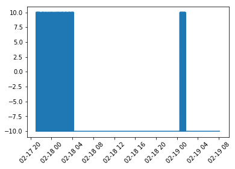

```python
plt.plot(DW.DateTime, DW.VarValue)# Shows only time for waste burning. Data not applicable for prediction.
plt.xticks(rotation=45) # this added
```

```python
FWA, m, n, = Filtvar(FWAsource, 'FOODWASTE_TANK_A_LEVEL_TREND')
```

```
sample size m= 67144
feature length n= 6
```

```python
FWB, m, n, = Filtvar(FWBsource, 'FOODWASTE_TANK_B_LEVEL_TREND')
```

```
sample size m= 67144
feature length n= 6
```

```python
FWA.head()
```

|  | VarName | TimeString | VarValue | Validity | Time_ms | DateTime |
| --- | --- | --- | --- | --- | --- | --- |
| 0 | FOODWASTE_TANK_A_LEVEL_TREND | 25.02.2018 16:07:23 | 47 | 1 | 43156671788,5185 | 2018-02-25 16:07:23 |
| 5 | FOODWASTE_TANK_A_LEVEL_TREND | 25.02.2018 16:07:28 | 47 | 1 | 43156671846,9907 | 2018-02-25 16:07:28 |
| 12 | FOODWASTE_TANK_A_LEVEL_TREND | 25.02.2018 16:07:33 | 47 | 1 | 43156671905,4745 | 2018-02-25 16:07:33 |
| 17 | FOODWASTE_TANK_A_LEVEL_TREND | 25.02.2018 16:07:38 | 47 | 1 | 43156671963,9583 | 2018-02-25 16:07:38 |
| 24 | FOODWASTE_TANK_A_LEVEL_TREND | 25.02.2018 16:07:43 | 47 | 1 | 43156672022,4421 | 2018-02-25 16:07:43 |

```python
FWA.tail()
```

|  | VarName | TimeString | VarValue | Validity | Time_ms | DateTime |
| --- | --- | --- | --- | --- | --- | --- |
| 402833 | FOODWASTE_TANK_A_LEVEL_TREND | 01.03.2018 14:19:11 | 35 | 1 | 43160596653,0324 | 2018-03-01 14:19:11 |
| 402840 | FOODWASTE_TANK_A_LEVEL_TREND | 01.03.2018 14:19:16 | 34 | 1 | 43160596711,5046 | 2018-03-01 14:19:16 |
| 402845 | FOODWASTE_TANK_A_LEVEL_TREND | 01.03.2018 14:19:21 | 35 | 1 | 43160596769,9884 | 2018-03-01 14:19:21 |
| 402852 | FOODWASTE_TANK_A_LEVEL_TREND | 01.03.2018 14:19:26 | 34 | 1 | 43160596828,4606 | 2018-03-01 14:19:26 |
| 402857 | FOODWASTE_TANK_A_LEVEL_TREND | 01.03.2018 14:19:31 | 33 | 1 | 43160596886,9329 | 2018-03-01 14:19:31 |

```python
# Analysis of FWA-data
print(FWA.columns)           # Columns for dataframe
print(type(FWA.columns))     # Column type
print(FWA.index)             # Index for the dataframe
print(type(FWA.index))       # Type of index of DF
print(FWA.iloc[:3,:])        # Splitting of 3 first index, inclusive
print(FWA.info())            # Datatype of each column
```

```
Index(['VarName', 'TimeString', 'VarValue', 'Validity', 'Time_ms', 'DateTime'], dtype='object')
<class 'pandas.core.indexes.base.Index'>
Int64Index([     0,      5,     12,     17,     24,     29,     36,     41,
                48,     53,
            ...
            402804, 402809, 402816, 402821, 402828, 402833, 402840, 402845,
            402852, 402857],
           dtype='int64', length=67144)
<class 'pandas.core.indexes.numeric.Int64Index'>
                         VarName           TimeString  VarValue  Validity  \
0   FOODWASTE_TANK_A_LEVEL_TREND  25.02.2018 16:07:23        47         1
5   FOODWASTE_TANK_A_LEVEL_TREND  25.02.2018 16:07:28        47         1
12  FOODWASTE_TANK_A_LEVEL_TREND  25.02.2018 16:07:33        47         1

             Time_ms            DateTime
0   43156671788,5185 2018-02-25 16:07:23
5   43156671846,9907 2018-02-25 16:07:28
12  43156671905,4745 2018-02-25 16:07:33
<class 'pandas.core.frame.DataFrame'>
Int64Index: 67144 entries, 0 to 402857
Data columns (total 6 columns):
VarName       67144 non-null object
TimeString    67144 non-null object
VarValue      67144 non-null int64
Validity      67144 non-null int64
Time_ms       67144 non-null object
DateTime      67144 non-null datetime64[ns]
dtypes: datetime64[ns](1), int64(2), object(3)
memory usage: 3.6+ MB
None
```

```python
# Analysis of FWB-data
print(FWB.columns)           # Columns for dataframe
print(type(FWB.columns))     # Column type
print(FWB.index)             # Index for the dataframe
print(type(FWB.index))       # Type of index of DF
print(FWB.iloc[:3,:])        # Splitting of 3 first index, inclusive
print(FWB.info())            # Datatype of each column
```

```
Index(['VarName', 'TimeString', 'VarValue', 'Validity', 'Time_ms', 'DateTime'], dtype='object')
<class 'pandas.core.indexes.base.Index'>
Int64Index([     0,      5,     12,     17,     24,     29,     36,     41,
                48,     53,
            ...
            402804, 402809, 402816, 402821, 402828, 402833, 402840, 402845,
            402852, 402857],
           dtype='int64', length=67144)
<class 'pandas.core.indexes.numeric.Int64Index'>
                         VarName           TimeString  VarValue  Validity  \
0   FOODWASTE_TANK_B_LEVEL_TREND  25.02.2018 16:07:23        14         1
5   FOODWASTE_TANK_B_LEVEL_TREND  25.02.2018 16:07:28        14         1
12  FOODWASTE_TANK_B_LEVEL_TREND  25.02.2018 16:07:33        15         1

             Time_ms            DateTime
0   43156671788,5185 2018-02-25 16:07:23
5   43156671847,0023 2018-02-25 16:07:28
12  43156671905,4745 2018-02-25 16:07:33
<class 'pandas.core.frame.DataFrame'>
Int64Index: 67144 entries, 0 to 402857
Data columns (total 6 columns):
VarName       67144 non-null object
TimeString    67144 non-null object
VarValue      67144 non-null int64
Validity      67144 non-null int64
Time_ms       67144 non-null object
DateTime      67144 non-null datetime64[ns]
dtypes: datetime64[ns](1), int64(2), object(3)
memory usage: 3.6+ MB
None
```

**PETRI: x-akselin hypistely**

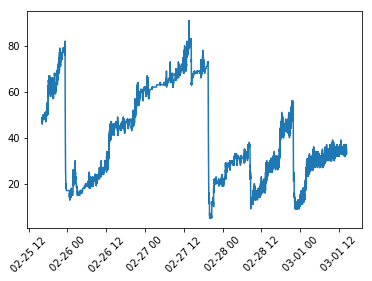

```python
plt.plot(FWA.DateTime, FWA.VarValue) # Discharge pumping can be seen in the plot
plt.xticks(rotation=45) # added
```

```python
FWB.head()
```

|  | VarName | TimeString | VarValue | Validity | Time_ms | DateTime |
| --- | --- | --- | --- | --- | --- | --- |
| 0 | FOODWASTE_TANK_B_LEVEL_TREND | 25.02.2018 16:07:23 | 14 | 1 | 43156671788,5185 | 2018-02-25 16:07:23 |
| 5 | FOODWASTE_TANK_B_LEVEL_TREND | 25.02.2018 16:07:28 | 14 | 1 | 43156671847,0023 | 2018-02-25 16:07:28 |
| 12 | FOODWASTE_TANK_B_LEVEL_TREND | 25.02.2018 16:07:33 | 15 | 1 | 43156671905,4745 | 2018-02-25 16:07:33 |
| 17 | FOODWASTE_TANK_B_LEVEL_TREND | 25.02.2018 16:07:38 | 14 | 1 | 43156671963,9699 | 2018-02-25 16:07:38 |
| 24 | FOODWASTE_TANK_B_LEVEL_TREND | 25.02.2018 16:07:43 | 15 | 1 | 43156672022,4421 | 2018-02-25 16:07:43 |

```python
FWB.tail()
```

|  | VarName | TimeString | VarValue | Validity | Time_ms | DateTime |
| --- | --- | --- | --- | --- | --- | --- |
| 402833 | FOODWASTE_TANK_B_LEVEL_TREND | 01.03.2018 14:19:11 | 21 | 1 | 43160596653,0324 | 2018-03-01 14:19:11 |
| 402840 | FOODWASTE_TANK_B_LEVEL_TREND | 01.03.2018 14:19:16 | 21 | 1 | 43160596711,5046 | 2018-03-01 14:19:16 |
| 402845 | FOODWASTE_TANK_B_LEVEL_TREND | 01.03.2018 14:19:21 | 21 | 1 | 43160596769,9884 | 2018-03-01 14:19:21 |
| 402852 | FOODWASTE_TANK_B_LEVEL_TREND | 01.03.2018 14:19:26 | 21 | 1 | 43160596828,4606 | 2018-03-01 14:19:26 |
| 402857 | FOODWASTE_TANK_B_LEVEL_TREND | 01.03.2018 14:19:31 | 21 | 1 | 43160596886,9329 | 2018-03-01 14:19:31 |

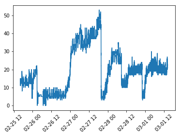

```python
plt.plot(FWB.DateTime, FWB.VarValue)
plt.xticks(rotation=45) # added
```

```python
BW, m, n, = Filtvar(BWsource, 'BIO_SLUDGE_TANK_LEVEL_TREND')
```

```
sample size m= 200476
feature length n= 6
```

```python
# Analysis of BW data
print(type(BW))
print(BW.columns)
print(BW.info())
```

```
<class 'pandas.core.frame.DataFrame'>
Index(['VarName', 'TimeString', 'VarValue', 'Validity', 'Time_ms', 'DateTime'], dtype='object')
<class 'pandas.core.frame.DataFrame'>
Int64Index: 200476 entries, 1 to 400951
Data columns (total 6 columns):
VarName       200476 non-null object
TimeString    200476 non-null object
VarValue      200476 non-null int64
Validity      200476 non-null int64
Time_ms       200476 non-null object
DateTime      200476 non-null datetime64[ns]
dtypes: datetime64[ns](1), int64(2), object(3)
memory usage: 10.7+ MB
None
```

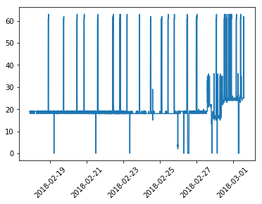

```python
plt.plot(BW.DateTime, BW.VarValue)# Data cannot be used!!!!
plt.xticks(rotation=45) # added
```

```python
def Diff(df):
    """
    Calculates difference between subsequent rows and adds the result created to Diff-column.
    In addition, removes NaN-values from the created Diff-column.
    Also, removes the discharge from level measurement: Removes negative value < -1
    and replaces the the values by zero


    :input: Name of the dataframe.

    :return: pandas dataframe with a new Diff-column containing difference between subsequent rows.

    """

    df['Diff'] = df.VarValue.diff()
    df.dropna(inplace=True)
    df.Diff.where(df.Diff > -2, 0, inplace=True)

    return df
```

```python
FW1 = Diff(FWA)
```

```python
FW2 = Diff(FWB)
```

```python
FW1.head()
```

|  | VarName | TimeString | VarValue | Validity | Time_ms | DateTime | Diff |
| --- | --- | --- | --- | --- | --- | --- | --- |
| 5 | FOODWASTE_TANK_A_LEVEL_TREND | 25.02.2018 16:07:28 | 47 | 1 | 43156671846,9907 | 2018-02-25 16:07:28 | 0.0 |
| 12 | FOODWASTE_TANK_A_LEVEL_TREND | 25.02.2018 16:07:33 | 47 | 1 | 43156671905,4745 | 2018-02-25 16:07:33 | 0.0 |
| 17 | FOODWASTE_TANK_A_LEVEL_TREND | 25.02.2018 16:07:38 | 47 | 1 | 43156671963,9583 | 2018-02-25 16:07:38 | 0.0 |
| 24 | FOODWASTE_TANK_A_LEVEL_TREND | 25.02.2018 16:07:43 | 47 | 1 | 43156672022,4421 | 2018-02-25 16:07:43 | 0.0 |
| 29 | FOODWASTE_TANK_A_LEVEL_TREND | 25.02.2018 16:07:48 | 47 | 1 | 43156672080,9028 | 2018-02-25 16:07:48 | 0.0 |

```python
FW2.head()
```

|  | VarName | TimeString | VarValue | Validity | Time_ms | DateTime | Diff |
| --- | --- | --- | --- | --- | --- | --- | --- |
| 5 | FOODWASTE_TANK_B_LEVEL_TREND | 25.02.2018 16:07:28 | 14 | 1 | 43156671847,0023 | 2018-02-25 16:07:28 | 0.0 |
| 12 | FOODWASTE_TANK_B_LEVEL_TREND | 25.02.2018 16:07:33 | 15 | 1 | 43156671905,4745 | 2018-02-25 16:07:33 | 1.0 |
| 17 | FOODWASTE_TANK_B_LEVEL_TREND | 25.02.2018 16:07:38 | 14 | 1 | 43156671963,9699 | 2018-02-25 16:07:38 | -1.0 |
| 24 | FOODWASTE_TANK_B_LEVEL_TREND | 25.02.2018 16:07:43 | 15 | 1 | 43156672022,4421 | 2018-02-25 16:07:43 | 1.0 |
| 29 | FOODWASTE_TANK_B_LEVEL_TREND | 25.02.2018 16:07:48 | 14 | 1 | 43156672080,9144 | 2018-02-25 16:07:48 | -1.0 |

```python
def cumV(df):
    """
    Calculates cumulative sum of differences V-% (Diff-column) and calculates cumulative sum
    of the waste flow by multiplying it with an effective tank volume.

    :input: Name of the dataframe.

    :return: pandas dataframe with incrVsum-column containing cumulative waste flow as m3.
    """

    # Cumulative sum of level increase as percent value
    # df['incrSum'] = df.Diff.cumsum()
    # Cumulative sum of level increase as m3
    df['incrVsum'] = df.Diff.cumsum() * 5 / 100

    return df
```

```python
cumV(FW1)
```

```python
cumV(FW2)
```

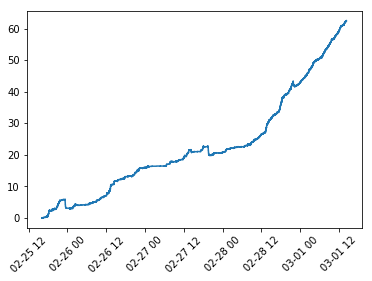

```python
plt.plot(FW1.DateTime, FW1.incrVsum)
plt.xticks(rotation=45) # added
```

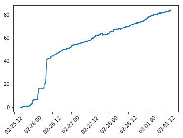

```python
plt.plot(FW2.DateTime, FW2.incrVsum)
plt.xticks(rotation=45) # added
```

```python
def rate(df):
    """
    Calculates flow rate of the waste stream as l/h and adds it to a new rate column.

    :input: Name of the dataframe.

    :return: pandas dataframe with new .
    """
    # Flow rate l/h from 1 h earlier to that moment
    df['lhFlow'] = df.incrVsum.diff(periods=720)*1000
    df.dropna(inplace=True)
    df.lhFlow.where(df.lhFlow > -2, 0, inplace=True)

    return df
```

```python
rate(FW1)
```

```python
rate(FW2)
```

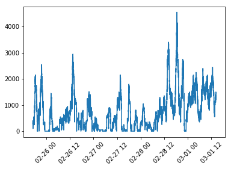

```python
plt.plot(FW1.DateTime, FW1.lhFlow)
plt.xticks(rotation=45) # added
```

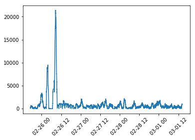

```python
plt.plot(FW2.DateTime, FW2.lhFlow)
plt.xticks(rotation=45) # added
```

```python
from sklearn.linear_model import LinearRegression

lm = LinearRegression(fit_intercept=False)
```

```python
# Type check: 1-dimensional that needs to convert to 2-dim. for fitting the model on data.
type(FW1.DateTime)
```

```
pandas.core.series.Series
```

```python
type(FW2.DateTime)
```

```
pandas.core.series.Series
```

**Solution: DateTime datatype needs to be converted to float-dtype to be able to fit the model:**

```python
# Conversion 0f DateTime to float
FW1['FloatingDateTime'] =FW1['DateTime'].apply(lambda x: x.timestamp())
```

```python
FW2['FloatingDateTime'] =FW2['DateTime'].apply(lambda x: x.timestamp())
```

```python
FW1.head()
```

|  | VarName | TimeString | VarValue | Validity | Time_ms | DateTime | Diff | incrVsum | lhFlow | FloatingDateTime |
| --- | --- | --- | --- | --- | --- | --- | --- | --- | --- | --- |
| 4325 | FOODWASTE_TANK_A_LEVEL_TREND | 25.02.2018 17:08:04 | 50 | 1 | 43156713934,7454 | 2018-02-25 17:08:04 | 0.0 | 0.3 | 300.0 | 1.519578e+09 |
| 4332 | FOODWASTE_TANK_A_LEVEL_TREND | 25.02.2018 17:08:09 | 50 | 1 | 43156713993,2176 | 2018-02-25 17:08:09 | 0.0 | 0.3 | 300.0 | 1.519578e+09 |
| 4337 | FOODWASTE_TANK_A_LEVEL_TREND | 25.02.2018 17:08:14 | 50 | 1 | 43156714051,6782 | 2018-02-25 17:08:14 | 0.0 | 0.3 | 300.0 | 1.519578e+09 |
| 4344 | FOODWASTE_TANK_A_LEVEL_TREND | 25.02.2018 17:08:19 | 50 | 1 | 43156714110,1505 | 2018-02-25 17:08:19 | 0.0 | 0.3 | 300.0 | 1.519578e+09 |
| 4349 | FOODWASTE_TANK_A_LEVEL_TREND | 25.02.2018 17:08:24 | 50 | 1 | 43156714168,6227 | 2018-02-25 17:08:24 | 0.0 | 0.3 | 300.0 | 1.519579e+09 |

```python
FW2.head()
```

|  | VarName | TimeString | VarValue | Validity | Time_ms | DateTime | Diff | incrVsum | lhFlow | FloatingDateTime |
| --- | --- | --- | --- | --- | --- | --- | --- | --- | --- | --- |
| 4325 | FOODWASTE_TANK_B_LEVEL_TREND | 25.02.2018 17:08:04 | 18 | 1 | 43156713934,7454 | 2018-02-25 17:08:04 | 0.0 | 0.3 | 300.0 | 1.519578e+09 |
| 4332 | FOODWASTE_TANK_B_LEVEL_TREND | 25.02.2018 17:08:09 | 18 | 1 | 43156713993,2176 | 2018-02-25 17:08:09 | 0.0 | 0.3 | 250.0 | 1.519578e+09 |
| 4337 | FOODWASTE_TANK_B_LEVEL_TREND | 25.02.2018 17:08:14 | 18 | 1 | 43156714051,6782 | 2018-02-25 17:08:14 | 0.0 | 0.3 | 300.0 | 1.519578e+09 |
| 4344 | FOODWASTE_TANK_B_LEVEL_TREND | 25.02.2018 17:08:19 | 18 | 1 | 43156714110,1505 | 2018-02-25 17:08:19 | 0.0 | 0.3 | 250.0 | 1.519578e+09 |
| 4349 | FOODWASTE_TANK_B_LEVEL_TREND | 25.02.2018 17:08:24 | 18 | 1 | 43156714168,6227 | 2018-02-25 17:08:24 | 0.0 | 0.3 | 300.0 | 1.519579e+09 |

```python
def inPort(df, arrival, departure):
    """
    Slices from the DataFrame the time period when the ship is in the port.

    :input: Name of the dataframe. Port arrival and departure as DateTime parameters in quotes ('').

    :return: pandas dataframe containing the data from the staying in port.
    """
    df1 = df.loc[df['DateTime'] > arrival]
    portTime = df1.loc[df1['DateTime'] < departure]

    return portTime
```

```python
FW1Port = inPort(FW1, '2018-02-26 07:00:00', '2018-02-26 17:00:00')
```

```python
FW1Port.head()
```

[output not shown]

```python
FW1Port.tail()
```

[output not shown]

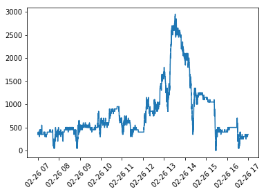

```python
plt.plot(FW1Port.DateTime, FW1Port.lhFlow)
plt.xticks(rotation=45) # added
```

```python
FW2Port = inPort(FW2, '2018-02-26 07:00:00', '2018-02-26 17:00:00')
```

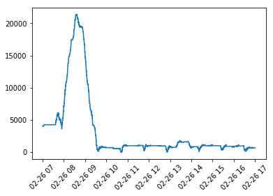

```python
plt.plot(FW2Port.DateTime, FW2Port.lhFlow)
plt.xticks(rotation=45) # added
```

```python
FWPort = pd.merge(FW1Port, FW2Port, on='DateTime')
```

```python
print(FWPort.columns)
```

[output not shown]

```python
FWPort['lhTot'] = FWPort.apply(lambda x: x['lhFlow_x'] + x['lhFlow_y'], axis=1)
```

**Combined flow of FW1 an FW2 in the port:**

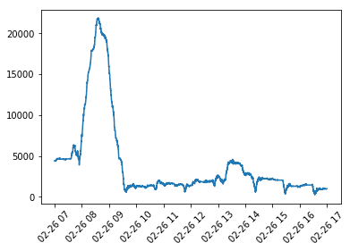

```python
plt.plot(FWPort.DateTime, FWPort.lhTot)
plt.xticks(rotation=45) # added
```

**Linear regression model for FW1 and FW2 in port condition:**

```python
Plm = LinearRegression(fit_intercept=False)
X1P = pd.DataFrame(FW1Port.FloatingDateTime)
y1P = pd.DataFrame(FW1Port.lhFlow)
Plm.fit(X1P, y1P)
FW1Port['P_pred'] = Plm.predict(X1P)
```

```python
type(FW1Port.P_pred.values) # D-type of prediction column
```

```
numpy.ndarray
```

```python
print(FW1Port.P_pred.iloc[0]) # <-- 1st degree predicted values
```

```
802.1595957468346
```

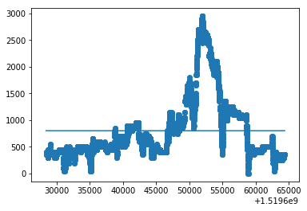

```python
# Plot the model against the data:
plt.plot(FW1Port.FloatingDateTime,FW1Port.P_pred,'-')
plt.scatter(FW1Port.FloatingDateTime,FW1Port.lhFlow)
```

```python
X2P = pd.DataFrame(FW2Port.FloatingDateTime)
y2P = pd.DataFrame(FW2Port.lhFlow)
Plm.fit(X2P, y2P)
FW2Port['P_pred'] = Plm.predict(X2P)
```

```python
type(FW2Port.P_pred.values) # D-type of prediction column
```

```
numpy.ndarray
```

```python
print(FW2Port.P_pred.iloc[0]) # <-- 1st degree predicted values
```

```
3193.6500664705245
```

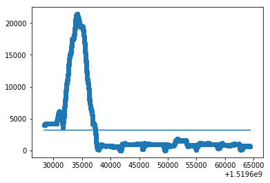

```python
# Plot the model against the data:
plt.plot(FW2Port.FloatingDateTime,FW2Port.P_pred,'-')
plt.scatter(FW2Port.FloatingDateTime,FW2Port.lhFlow)
```

**Polynomial regression model combined FW flow in port condition:**

```python
from sklearn.preprocessing import PolynomialFeatures
```

```python
poly_regP = PolynomialFeatures(degree=4)
```

```python
XP = pd.DataFrame(FWPort.FloatingDateTime_x)
yP = pd.DataFrame(FWPort.lhTot)
```

```python
X_polyP = poly_regP.fit_transform(XP)
```

```python
pol_reg = LinearRegression()
```

```python
pol_reg.fit(X_polyP, yP)
```

```
LinearRegression(copy_X=True, fit_intercept=True, n_jobs=None,
         normalize=False)
```

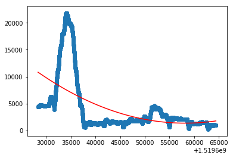

```python
# Plot the polynomial model against the data:
plt.plot(XP,pol_reg.predict(X_polyP), color='red')
plt.scatter(FWPort.FloatingDateTime_x,FWPort.lhTot)
```

```python
from sklearn.pipeline import make_pipeline
```

```python
poly_modelP = make_pipeline(PolynomialFeatures(4), LinearRegression())
poly_modelP.fit(X_polyP, yP)
yPfit = poly_modelP.predict(X_polyP)
```

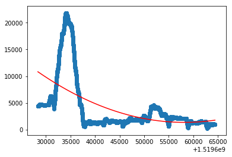

```python
# Plot the sklearn.pipeline-based polynomial model against the data:
plt.plot(XP,yPfit, color='red')
plt.scatter(FWPort.FloatingDateTime_x,FWPort.lhTot)
```

**Conclusion: different method did not change the model that much**